# Data manipulation via tidyverse (focus on readr, dplyr)

You Ye

2022-07-11

# Outline

- Data Import with readr
- Tibbles with tibble
- Data Transformation with dplyr

[figure not shown]

# Readr

main package: library(**tidyverse**)

- read_csv() –> comma-delimited files
- read_csv2() –> semicolon-separated files
- read_tsv() –> tab-delimited files
- read_delim() –>any delimiter files
- read_fwf() –>fixed-width files
- read_table() –>fixed-width files, separated by white space
- read_log() –>Apache style log files(need package: webreadr)

# read_csv usage

- read_csv(

  file,

  col_names = TRUE,

  col_types = NULL,

  col_select = NULL,

  id = NULL,

  locale = default_locale(),

  na = c(““,”NA”),

  quoted_na = TRUE,

  quote = “\”“,

  comment = ““,

  trim_ws = TRUE,

  skip = 0,

  n_max = Inf,

  guess_max = min(1000, n_max),

  name_repair = “unique”,

  num_threads = readr_threads(),

  progress = show_progress(),

  show_col_types = should_show_types(),

  skip_empty_rows = TRUE,

  lazy = should_read_lazy()

  )

# Some example for read_csv

```r
library(readr)
#can use setwd() to fix default path
lbtest <- read_csv("lbtest.csv")
```

```r
lbtest <- read_csv("D:/Users/You.Ye/OneDrive - FMD K&L Inc/Documents/share/R_practise/data/lbtest.csv")
```

- use inline CSV file
- The first line will set into column name in default

```r
read_csv("a,b,c
1,2,3
4,5,6")
```

```
## # A tibble: 2 x 3
##       a     b     c
##   <dbl> <dbl> <dbl>
## 1     1     2     3
## 2     4     5     6
```

```r
read_csv("
1,2,3
4,5,6")
```

```
## # A tibble: 1 x 3
##     `1`   `2`   `3`
##   <dbl> <dbl> <dbl>
## 1     4     5     6
```

- use skip = n to skip the first n lines

```r
read_csv("The first line of metadata
The second line of metadata
x,y,z
1,2,3", skip = 2)
```

```
## # A tibble: 1 x 3
##       x     y     z
##   <dbl> <dbl> <dbl>
## 1     1     2     3
```

- use comment = “#” to drop all lines that start with (e.g.) #:

```r
read_csv("# A comment I want to skip
x,y,z
1,2,3", comment = "#")
```

```
## # A tibble: 1 x 3
##       x     y     z
##   <dbl> <dbl> <dbl>
## 1     1     2     3
```

- use col_names= FALSE, set column names sequentially from X1 to Xn
- “\n” is a convenient shortcut for adding a new line

```r
read_csv("1,2,3\n4,5,6", col_names = FALSE)
```

```
## # A tibble: 2 x 3
##      X1    X2    X3
##   <dbl> <dbl> <dbl>
## 1     1     2     3
## 2     4     5     6
```

- specifies missing values

```r
read_csv("a,b,c\n1,2,.", na = ".")
```

```
## # A tibble: 1 x 3
##       a     b c
##   <dbl> <dbl> <lgl>
## 1     1     2 NA
```

```r
read_csv("a,b,c\n1,2,.")
```

```
## # A tibble: 1 x 3
##       a     b c
##   <dbl> <dbl> <chr>
## 1     1     2 .
```

# Parsing a Vector: parse_*() functions

- parse_*(): These functions take a character vector and return a more specialized vector like a logical, integer, or date.
- **str(object, …):** Compactly display the internal structure of an R object, a diagnostic function and an alternative to summary
- parse_logical()
- parse_integer()
- parse_double()
- parse_number()
- parse_character()
- parse_factor()
- parse_datetime()
- parse_date()
- parse_time()
- logical: T /F /TRUE /FALSE /NA /0 /1

```r
str(parse_logical(c("TRUE", "FALSE", "NA","T","F","1","0")))
```

```
##  logi [1:7] TRUE FALSE NA TRUE FALSE TRUE ...
```

- If parsing fails, the failures will be missing in the output

```r
str(parse_date(c("TRUE", "FALSE", "NA")))
```

```
##  Date[1:3], format: NA NA NA
```

- The na argument can specifies which strings should be treated as missing

```r
str(parse_integer(c("1", "2", "3")))
```

```
##  int [1:3] 1 2 3
```

```r
parse_integer(c("1", "231", ".", "456"))
```

```
## [1]   1 231  NA 456
## attr(,"problems")
## # A tibble: 1 x 4
##     row   col expected               actual
##   <int> <int> <chr>                  <chr>
## 1     3    NA no trailing characters .
```

```r
parse_integer(c("1", "231", ".", "456"), na = ".")
```

```
## [1]   1 231  NA 456
```

```r
str(parse_date(c("2010-01-01", "1979/10/14")))
```

```
##  Date[1:2], format: "2010-01-01" "1979-10-14"
```

# Numbers

- Parse 1,000,000/1.45/it cost $10 to num
- The default decimal mark is “.”, decimal_mark argument can override the default value of .

```r
parse_number("123,456789",locale = locale(decimal_mark = ","))
```

```
## [1] 123.4568
```

- grouping_mark define the symbol separated the number

```r
parse_number("123.456.789",locale = locale(grouping_mark = "."))
```

```
## [1] 123456789
```

- grouping_mark and decimal_mark can not use the same symbol

```r
parse_number("1.234,56", locale = locale(decimal_mark = ".", grouping_mark = ","))
```

```
## [1] 1.23456
```

- It ignores non numeric characters before and after the number
- If multiple numbers in one string, extract the first number

```r
parse_number("it cost $10")
```

```
## [1] 10
```

```r
parse_number("it cost $1$0 $100")
```

```
## [1] 1
```

# Strings

- parse_character() should be really simple—it could just return its input
- locale(encoding= ): specify the encoding in parse_character(): when the print results are gibberish

```r
parse_character('Hello 567')
```

```
## [1] "Hello 567"
```

```r
parse_character("Hello 世界",locale=locale(encoding="GBK"))
```

```
## [1] "Hello 世界"
```

```r
parse_character("Hello 世界",locale=locale(encoding="UTF-8"))
```

```
## [1] "Hello <ca>=<e7>"
```

- charToRaw(): return the ASCII

```r
charToRaw("Hello 世界")
```

```
##  [1] 48 65 6c 6c 6f 20 ca c0 bd e7
```

```r
guess_encoding(charToRaw("Hello 世界"))
```

```
## # A tibble: 3 x 2
##   encoding     confidence
##   <chr>             <dbl>
## 1 ISO-8859-1         0.27
## 2 ISO-8859-7         0.27
## 3 windows-1251       0.27
```

```r
parse_character("Hello 世界",locale=locale(encoding="ISO-8859-7"))
```

```
## [1] "Hello Κΐ½η"
```

```r
parse_character("Hello 世界",locale=locale(encoding="UTF-8"))
```

```
## [1] "Hello <ca>=<e7>"
```

# Factors

- R uses factors to represent categorical variables that have a known set of possible values.

```r
fruit <- c("apple", "banana","pineapple")
parse_factor(c("apple", "banana", "bananana"), levels = fruit)
```

```
## [1] apple  banana <NA>
## attr(,"problems")
## # A tibble: 1 x 4
##     row   col expected           actual
##   <int> <int> <chr>              <chr>
## 1     3    NA value in level set bananana
## Levels: apple banana pineapple
```

```r
parse_factor(c("apple", "banana"), levels = fruit)
```

```
## [1] apple  banana
## Levels: apple banana pineapple
```

# Dates, Date-Times, and Times

- The first day in SAS system: 1960-01-01
- The first day in R system: 1970-01-01
- parse_datetime() expects an ISO8601 date-time
- parse_date() expects a four-digit year, a - or /, the month, a - or /, then the day
- parse_time() expects the hour, :, minutes, optionally : and seconds, and an optional a.m./p.m. specifier
- User-defined formats can also be recognized, if built up of the following pieces:

- ```
    Year
        %Y (4 digits).
        %y (2 digits; 00-69 → 2000-2069, 70-99 → 1970-1999).
  ```

- ```
    Month
        %m (2 digits).
        %b (abbreviated name, like "Jan").
        %B (full name, "January").
  ```

- ```
    Day
        %d (2 digits).
        %e (optional leading space).
  ```

- ```
    Time
        %H (0-23 hour format).
        %I (0-12, must be used with %p).
        %p (a.m./p.m. indicator).
        %M (minutes).
        %S (integer seconds).
        %OS (real seconds).
        %Z (time zone [a name, e.g., America/Chicago]).
        %z (as offset from UTC, e.g., +0800).
  ```

- ```
    Nondigits
        %. (skips one nondigit character).
        %\* (skips any number of nondigits).
  ```

- If you’re using %b or %B with non-English month names, you’ll need to set the lang argument to locale().
- See the list of built-in languages in date_names_langs().

```r
parse_datetime("2010-10-01T2010")
```

```
## [1] "2010-10-01 20:10:00 UTC"
```

```r
parse_datetime("20101010")
```

```
## [1] "2010-10-10 UTC"
```

```r
parse_date("2010/10-01")
```

```
## [1] "2010-10-01"
```

```r
parse_time("01:10 pm")
```

```
## 13:10:00
```

```r
parse_date("220101",locale=locale(date_format = "%y%m%e"))
```

```
## [1] "2022-01-01"
```

```r
au_locale <- locale(date_format = "%d/%m/%Y")
parse_date("02/01/2006", locale = au_locale)
```

```
## [1] "2006-01-02"
```

```r
parse_date("1 janvier 2015", "%d %B %Y", locale = locale("fr"))
```

```
## [1] "2015-01-01"
```

# Parsing a File

- Reads the first 1000 rows
- guess_parser(): returns readr’s best guess
- parse_guess(): guess to parse the column
- The heuristic tries each of the following types, stopping when it finds a match:

- ```
    logical
      Contains only “F”, “T”, “FALSE”, or “TRUE”.
  ```

- ```
    integer
      Contains only numeric characters (and -).
  ```

- ```
    double
      Contains only valid doubles (including numbers like 4.5e-5).
  ```

- ```
    number
      Contains valid doubles with the grouping mark inside.
  ```

- ```
    time
      Matches the default time_format.
  ```

- ```
    date
      Matches the default date_format.
  ```

- ```
    date-time
      Any ISO8601 date.
  ```

- ```
    strings
  ```

- tail(x, …)/head(x, …): Returns the first or last parts of a vector, matrix, table, data frame or function.
- guess_max = 1000+
- col_types = cols(.default = col_character()+type_convert()

```r
challenge <- read_csv(readr_example("challenge.csv"))
problems(challenge)
```

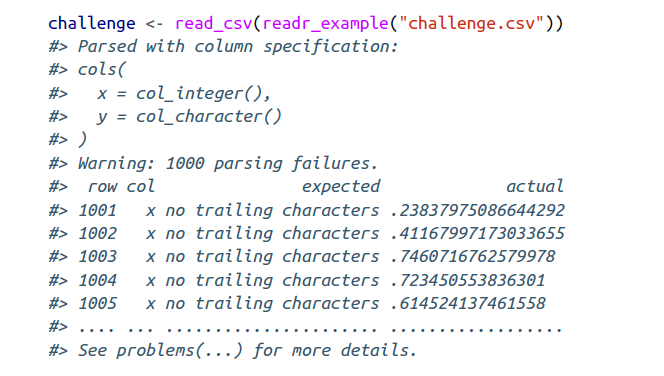

- It’s highly recommend always supplying col_types, building up from the printout provided by readr

```r
challenge <- read_csv(
readr_example("challenge.csv"),
col_types = cols(
x = col_double(),
y = col_date()
)
)
```

- type_convert(): If the data type is unknown first, can set data type to character, then use it to see the most likely data type

```r
challenge2 <- read_csv(readr_example("challenge.csv"),
col_types = cols(.default = col_character())
)

challenge2
```

```
## # A tibble: 2,000 x 2
##    x     y
##    <chr> <chr>
##  1 404   <NA>
##  2 4172  <NA>
##  3 3004  <NA>
##  4 787   <NA>
##  5 37    <NA>
##  6 2332  <NA>
##  7 2489  <NA>
##  8 1449  <NA>
##  9 3665  <NA>
## 10 3863  <NA>
## # ... with 1,990 more rows
```

```r
type_convert(challenge2)
```

```
## # A tibble: 2,000 x 2
##        x y
##    <dbl> <date>
##  1   404 NA
##  2  4172 NA
##  3  3004 NA
##  4   787 NA
##  5    37 NA
##  6  2332 NA
##  7  2489 NA
##  8  1449 NA
##  9  3665 NA
## 10  3863 NA
## # ... with 1,990 more rows
```

# Writing to a File

- some important write_* function: write_csv()/write_tsv()/write_excel_csv()
- Simple but will lose type information

```r
write_csv(challenge, "challenge.csv")
```

- Store data in R’s custom binary format called RDS

```r
write_rds(challenge, "challenge.rds")
read_rds("challenge.rds")

library(feather)
write_feather(challenge, "challenge.feather")
read_feather("challenge.feather")
```

# Other Types of Data

- **haven** reads SPSS, Stata, and SAS files
- **foreign** reads SPSS, Stata, and SAS files
- **readxl** reads Excel files (both .xls and .xlsx).

## readxl

```r
#install.packages("readxl")
library("readxl")
#?read_excel
lbtest<-read_excel("LBTEST.xlsx")
lbtest<-read_xlsx("LBTEST.xlsx")
```

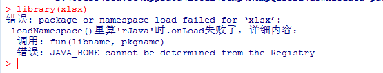

- https://blog.csdn.net/wqdwin/article/details/75386673

## haven

- haven read_sas() can keep label

```r
#install.packages('haven')
library("haven")
adsl<-read_sas("adsl.sas7bdat")
write_sas(adsl,"adsl2.sas7bdat")
```

## sas7bdat

```r
#read.sas7bdat() will lose label
#install.packages("sas7bdat")
library("sas7bdat")
adsl2<-read.sas7bdat("adsl.sas7bdat")
```

# tibble

main package: library(**tidyverse**) Tibbles are data frames, but they tweak some older behaviors to make life a little easier

- as_tibble() (e.g. as_tibble(iris))
- tibble()
- tribble()

# tibble()

- Create a new tibble from individual vectors.
- Tibble() will automatically recycle inputs of length 1.
- Allows you to refer to variables that you just created.
- can use invalid R variable names: surround them with backticks `.

```r
library(tidyverse)

tibble(
  x = 1:5,
  y = 1,
  z = x ^ 2 + y
)
```

```
## # A tibble: 5 x 3
##       x     y     z
##   <int> <dbl> <dbl>
## 1     1     1     2
## 2     2     1     5
## 3     3     1    10
## 4     4     1    17
## 5     5     1    26
```

```r
(tb <- tibble(
`:)` = "smile",
` ` = "space",
`2000` = "number"
))
```

```
## # A tibble: 1 x 3
##   `:)`  ` `   `2000`
##   <chr> <chr> <chr>
## 1 smile space number
```

# tribble()

- column headings are defined by formulas (i.e., they start with ~)
- entries are separated by commas

```r
library(tidyverse)
tribble(
~x, ~y, ~z,
#--|--|----
"a", 2, 3.6,
"b", 1, 8.5
)
```

```
## # A tibble: 2 x 3
##   x         y     z
##   <chr> <dbl> <dbl>
## 1 a         2   3.6
## 2 b         1   8.5
```

# Tibbles Versus data.frame

- Printing: shows only the first 10 rows and all the columns that fit on screen
- Subsetting: need use $ and [[ to pull out a single variable
- Control the default print behavior by setting options options(tibble.print_max = n, tibble.print_min = m) options(tibble.print_min = Inf) options(tibble.width = Inf)

```r
library(tidyverse)

tibble(
a = lubridate::now() + runif(1e3) * 86400,
b = lubridate::today() + runif(1e3) * 30,
c = 1:1e3,
d = runif(1e3),
e = sample(letters, 1e3, replace = TRUE)
)
```

```
## # A tibble: 1,000 x 5
##    a                   b              c      d e
##    <dttm>              <date>     <int>  <dbl> <chr>
##  1 2022-09-16 11:52:10 2022-10-06     1 0.215  m
##  2 2022-09-16 12:10:03 2022-10-12     2 0.904  i
##  3 2022-09-15 19:47:53 2022-09-25     3 0.0273 v
##  4 2022-09-15 21:52:05 2022-09-24     4 0.679  m
##  5 2022-09-16 10:39:32 2022-10-05     5 0.190  z
##  6 2022-09-16 09:26:03 2022-09-22     6 0.919  p
##  7 2022-09-15 19:58:12 2022-10-03     7 0.524  c
##  8 2022-09-16 10:57:03 2022-10-02     8 0.695  t
##  9 2022-09-16 03:04:40 2022-10-14     9 0.362  j
## 10 2022-09-16 03:45:30 2022-10-11    10 0.831  s
## # ... with 990 more rows
```

- width = Inf will display all columns

```r
nycflights13::flights %>%
  print(n = 10, width = Inf)
```

```
## # A tibble: 336,776 x 19
##     year month   day dep_time sched_dep_time dep_delay arr_time sched_arr_time arr_delay carrier flight tailnum origin dest
##    <int> <int> <int>    <int>          <int>     <dbl>    <int>          <int>     <dbl> <chr>    <int> <chr>   <chr>  <chr>
##  1  2013     1     1      517            515         2      830            819        11 UA        1545 N14228  EWR    IAH
##  2  2013     1     1      533            529         4      850            830        20 UA        1714 N24211  LGA    IAH
##  3  2013     1     1      542            540         2      923            850        33 AA        1141 N619AA  JFK    MIA
##  4  2013     1     1      544            545        -1     1004           1022       -18 B6         725 N804JB  JFK    BQN
##  5  2013     1     1      554            600        -6      812            837       -25 DL         461 N668DN  LGA    ATL
##  6  2013     1     1      554            558        -4      740            728        12 UA        1696 N39463  EWR    ORD
##  7  2013     1     1      555            600        -5      913            854        19 B6         507 N516JB  EWR    FLL
##  8  2013     1     1      557            600        -3      709            723       -14 EV        5708 N829AS  LGA    IAD
##  9  2013     1     1      557            600        -3      838            846        -8 B6          79 N593JB  JFK    MCO
## 10  2013     1     1      558            600        -2      753            745         8 AA         301 N3ALAA  LGA    ORD
##    air_time distance  hour minute time_hour
##       <dbl>    <dbl> <dbl>  <dbl> <dttm>
##  1      227     1400     5     15 2013-01-01 05:00:00
##  2      227     1416     5     29 2013-01-01 05:00:00
##  3      160     1089     5     40 2013-01-01 05:00:00
##  4      183     1576     5     45 2013-01-01 05:00:00
##  5      116      762     6      0 2013-01-01 06:00:00
##  6      150      719     5     58 2013-01-01 05:00:00
##  7      158     1065     6      0 2013-01-01 06:00:00
##  8       53      229     6      0 2013-01-01 06:00:00
##  9      140      944     6      0 2013-01-01 06:00:00
## 10      138      733     6      0 2013-01-01 06:00:00
## # ... with 336,766 more rows
```

- Compared to a data.frame, tibbles are more strict: they never do partial matching
- It will generate a warning if the column does not exist.

```r
df <- tibble(
x = runif(5),
y = rnorm(5)
)
df
```

```
## # A tibble: 5 x 2
##       x      y
##   <dbl>  <dbl>
## 1 0.790 -0.530
## 2 0.616 -0.257
## 3 0.410  0.751
## 4 0.948 -1.64
## 5 0.713 -1.53
```

- Extract variables by name

```r
df$x
```

```
## [1] 0.7904774 0.6163127 0.4096114 0.9477570 0.7125392
```

```r
df[["x"]]
```

```
## [1] 0.7904774 0.6163127 0.4096114 0.9477570 0.7125392
```

- Extract variables by position

```r
df[[1]]
```

```
## [1] 0.7904774 0.6163127 0.4096114 0.9477570 0.7125392
```

- if use with %>%, need .

```r
df %>% .$x
```

```
## [1] 0.7904774 0.6163127 0.4096114 0.9477570 0.7125392
```

```r
df %>% .[["x"]]
```

```
## [1] 0.7904774 0.6163127 0.4096114 0.9477570 0.7125392
```

```r
df %>% .[[1]]
```

```
## [1] 0.7904774 0.6163127 0.4096114 0.9477570 0.7125392
```

# Interacting with Older Code

- as.data.frame(): turn a tibble back to a data.frame (e.g. as.data.frame(tb))

# dplyr

main package: library(**tidyverse**)

[figure not shown]

- filter() –> Pick observations by their values
- arrange() –> Reorder the rows
- select() –> Pick variables by their names
- mutate() –> Create new variables with functions of existing variables
- summarize() –> Collapse many values down to a single summary

# filter()

```r
library(nycflights13)
library(tidyverse)
filter(flights, month == 1, day != 1)
```

- R either prints out the results, or saves them to a variable. If you want to do both, you can wrap the assignment in parentheses

```r
jan1 <- filter(flights, month == 1, day == 1)
View(jan1)
(jan1 <- filter(flights, month == 1, day == 1))
```

- Computers use finite precision arithmetic (they obviously can’t store an infinite number of digits)

```r
filter(flights, month == 1, day == 4/2)
filter(flights, month == 1, day == 0.5*2)
filter(flights, month == 1, day == 1/49*49) #A tibble:0 x 19
filter(flights, month == 1, near(3 / 49 * 49, day))
```

- | , %in%

```r
filter(flights, month == 2|3) #filter month=1
filter(flights, month == 2| month == 3) #filter month=2 or 3
filter(flights, month %in% c(2,3)) #filter month=2 or 3
filter(flights, carrier %in% c('9E', 'AA'))
```

- between

```r
filter(flights, month > 1& month<4)
#filter(flights, 1< month<4) #error
filter(flights, between(month,2,3))
```

- missing
- filter() only includes rows where the condition is TRUE; it excludes both FALSE and NA values

```r
df <- tibble(x = c(1, NA, 3))
filter(df, x > 1)
```

```
## # A tibble: 1 x 1
##       x
##   <dbl>
## 1     3
```

```r
filter(df, is.na(x))
```

```
## # A tibble: 1 x 1
##       x
##   <dbl>
## 1    NA
```

```r
filter(df, !is.na(x))
```

```
## # A tibble: 2 x 1
##       x
##   <dbl>
## 1     1
## 2     3
```

```r
filter(df, x > 1|is.na(x))
```

```
## # A tibble: 2 x 1
##       x
##   <dbl>
## 1    NA
## 2     3
```

# arrange()

```r
library(nycflights13)
library(tidyverse)
arrange(flights, year, month, day)
#desc()
arrange(flights, desc(arr_delay))
```

- Missing values are always sorted at the end

```r
df <- tibble(x = c(5, 2, NA))
arrange(df, x)
```

```
## # A tibble: 3 x 1
##       x
##   <dbl>
## 1     2
## 2     5
## 3    NA
```

```r
arrange(df, desc(x))
```

```
## # A tibble: 3 x 1
##       x
##   <dbl>
## 1     5
## 2     2
## 3    NA
```

- How could you use arrange() to sort all missing values to the start?

```r
arrange(df,desc(is.na(x)),x)
```

```
## # A tibble: 3 x 1
##       x
##   <dbl>
## 1    NA
## 2     2
## 3     5
```

# select()

- **starts_with**(“abc”) matches names that begin with “abc”.
- **ends_with**(“xyz”) matches names that end with “xyz”.
- **contains**(“ijk”) matches names that contain “ijk”.
- **matches**(“(.)\1”) selects variables that match a regular expression.
- **num_range**(“x”, 1:3) matches x1, x2, and x3.

```r
library(nycflights13)
library(tidyverse)
select(flights, year, month, day)

# Select all columns between year and day
select(flights, year:day)

# Select all columns except those from year to day
select(flights, -(year:day))

# Select all columns except year and day
select(flights, -c('year','day'))

# Select all columns start with 'arr_'
select(flights, starts_with("arr_"))
```

- rename(data, new_name = old_name)

```r
library(nycflights13)
library(tidyverse)
rename(flights, tail_num = tailnum)
```

- Fix the position of variables: move some variables to the start of the data frame

```r
library(nycflights13)
library(tidyverse)
select(flights, time_hour, air_time, everything())
```

```
## # A tibble: 336,776 x 19
##    time_hour           air_time  year month   day dep_time sched_dep_time dep_delay arr_time sched_arr_time arr_delay carrier
##    <dttm>                 <dbl> <int> <int> <int>    <int>          <int>     <dbl>    <int>          <int>     <dbl> <chr>
##  1 2013-01-01 05:00:00      227  2013     1     1      517            515         2      830            819        11 UA
##  2 2013-01-01 05:00:00      227  2013     1     1      533            529         4      850            830        20 UA
##  3 2013-01-01 05:00:00      160  2013     1     1      542            540         2      923            850        33 AA
##  4 2013-01-01 05:00:00      183  2013     1     1      544            545        -1     1004           1022       -18 B6
##  5 2013-01-01 06:00:00      116  2013     1     1      554            600        -6      812            837       -25 DL
##  6 2013-01-01 05:00:00      150  2013     1     1      554            558        -4      740            728        12 UA
##  7 2013-01-01 06:00:00      158  2013     1     1      555            600        -5      913            854        19 B6
##  8 2013-01-01 06:00:00       53  2013     1     1      557            600        -3      709            723       -14 EV
##  9 2013-01-01 06:00:00      140  2013     1     1      557            600        -3      838            846        -8 B6
## 10 2013-01-01 06:00:00      138  2013     1     1      558            600        -2      753            745         8 AA
## # ... with 336,766 more rows, and 7 more variables: flight <int>, tailnum <chr>, origin <chr>, dest <chr>, distance <dbl>,
## #   hour <dbl>, minute <dbl>
```

# mutate()

- **Arithmetic operators**: +, -, *, /, ^
- **Modular arithmetic**: (%/% and %%)
- **logs**: log(), log2(), log10()
- **Offsets**: lead(), lag()
- **Cumulative and rolling aggregates**: cumsum(), cumprod(), cummin(), cummax()
- **Logical comparisons**: <, <=, >, >=, !=
- **Ranking**: min_rank(), row_number(), dense_rank(), percent_rank(), cume_dist(), ntile()
- You can refer to columns that you’ve just created

```r
mutate(flights,
gain = arr_delay - dep_delay,
hours = air_time / 60,
gain_per_hour = gain / hours
)
```

- transmute(): If you only want to keep the new variables

```r
transmute(flights,
gain = arr_delay - dep_delay,
hours = air_time / 60,
gain_per_hour = gain / hours
)
```

```r
transmute(flights,
dep_time,
hour = dep_time %/% 100,
minute = dep_time %% 100
)
```

- Offsets

```r
(x <- 1:10)
```

```
##  [1]  1  2  3  4  5  6  7  8  9 10
```

```r
lag(x)
```

```
##  [1] NA  1  2  3  4  5  6  7  8  9
```

```r
lead(x)
```

```
##  [1]  2  3  4  5  6  7  8  9 10 NA
```

- rank
- The default gives the smallest values the smallest ranks;
- Use desc(x) to give the largest values the smallest ranks

```r
y <- c(1, 2, 2, NA, 3, 4)
min_rank(y)
```

```
## [1]  1  2  2 NA  4  5
```

```r
min_rank(desc(y))
```

```
## [1]  5  3  3 NA  2  1
```

# summarize()

- It collapses a data frame to a single row
- Useful functions Center: mean(), median() Spread: sd(), IQR(), mad() Range: min(), max(), quantile() Position: first(), last(), nth(), Count: n(), n_distinct() Logical: any(), all()
- group_by()
- na.rm=T/F
- %>%: x %>% f(y) turns into f(x, y), x %>% f(y) %>% g(z) turns into g(f(x, y), z)
- If there’s any missing value in the input, the output will be a missing value

```r
summarize(flights, delay = mean(dep_delay, na.rm = TRUE))
summarize(flights, delay = mean(dep_delay))
```

- use %>% and group_by

```r
library(nycflights13)
library(tidyverse)
flights %>%
group_by(year, month, day) %>%
summarize(mean = mean(dep_delay, na.rm = TRUE))
```

- use %>% and subsetting

```r
library(nycflights13)
library(tidyverse)
flights %>%
  filter(!is.na(dep_delay), !is.na(arr_delay))%>%
  group_by(year, month, day) %>%
  summarize(
  # average delay:
  avg_delay1 = mean(arr_delay),
  # average positive delay:
  avg_delay2 = mean(arr_delay[arr_delay > 0])
)
```

- min(x), quantile(x, 0.25), max(x)
- quantile(x, 0.25) represent Q1

```r
library(nycflights13)
library(tidyverse)
# Q1
flights %>%
  filter(!is.na(dep_delay), !is.na(arr_delay))%>%
  group_by(year, month, day) %>%
  summarize(
  qua_arr = quantile(arr_delay, 0.25),
)

# Q3
flights %>%
  filter(!is.na(dep_delay), !is.na(arr_delay))%>%
  group_by(year, month, day) %>%
  summarize(
  qua_arr = quantile(arr_delay, 0.75),
)

#Q2=median
flights %>%
  filter(!is.na(dep_delay), !is.na(arr_delay))%>%
  group_by(year, month, day) %>%
  summarize(
  qua_arr = quantile(arr_delay, 0.5),
)

flights %>%
  filter(!is.na(dep_delay), !is.na(arr_delay))%>%
  group_by(year, month, day) %>%
  summarize(
  qua_arr = median(arr_delay),
)
```

- position first(x), nth(x, 2), last(x)

```r
library(nycflights13)
library(tidyverse)
flights %>%
  filter(!is.na(dep_delay), !is.na(arr_delay))%>%
  group_by(year, month, day) %>%
  summarize(
  first_dep = first(dep_time),
  last_dep = last(dep_time)
)
```

- rank
- range(): range returns a vector containing the minimum and maximum of all the given arguments.

```r
library(nycflights13)
library(tidyverse)
flights %>%
  filter(!is.na(dep_delay), !is.na(arr_delay))%>%
  group_by(year, month, day) %>%
  mutate(r = min_rank(desc(dep_time))) %>%
  filter(r %in% range(r))%>%
  select(dep_time,r,everything())
```

- n() / sum(!is.na(x)) / n_distinct

```r
library(nycflights13)
library(tidyverse)
flights %>%
  filter(!is.na(dep_delay), !is.na(arr_delay))%>%
  group_by(dest) %>%
  summarize(carriers_unique = n_distinct(carrier),carriers = n(),carries2=sum(!is.na(carrier)))%>%
  arrange(desc(carriers))
```

- count()

```r
library(nycflights13)
library(tidyverse)

# count()
flights %>%
  filter(!is.na(dep_delay), !is.na(arr_delay))%>%
  count(dest)

# add a weight variable-->sum
flights %>%
  filter(!is.na(dep_delay), !is.na(arr_delay))%>%
  count(tailnum, wt = distance)
```

- summarize + logical

```r
library(nycflights13)
library(tidyverse)

# logical
flights %>%
  filter(!is.na(dep_delay), !is.na(arr_delay))%>%
  group_by(year, month, day) %>%
  summarize(n_early = sum(dep_time < 500))

# percent
flights %>%
  filter(!is.na(dep_delay), !is.na(arr_delay))%>%
  group_by(year, month, day) %>%
  summarize(hour_perc = mean(arr_delay > 60))
```

# Grouping by Multiple Variables

- note: The sum of groupwise sums is the overall sum, but the median of groupwise medians is not the overall median.

```r
library(nycflights13)
library(tidyverse)

daily <- group_by(flights, year, month, day)
(per_day <- summarize(daily, mdist = mean(distance)))
```

```
## # A tibble: 365 x 4
## # Groups:   year, month [12]
##     year month   day mdist
##    <int> <int> <int> <dbl>
##  1  2013     1     1 1077.
##  2  2013     1     2 1053.
##  3  2013     1     3 1037.
##  4  2013     1     4 1032.
##  5  2013     1     5 1068.
##  6  2013     1     6 1052.
##  7  2013     1     7  998.
##  8  2013     1     8  986.
##  9  2013     1     9  981.
## 10  2013     1    10  993.
## # ... with 355 more rows
```

```r
(per_month <- summarize(per_day, mdist = mean(mdist)))
```

```
## # A tibble: 12 x 3
## # Groups:   year [1]
##     year month mdist
##    <int> <int> <dbl>
##  1  2013     1 1008.
##  2  2013     2 1003.
##  3  2013     3 1014.
##  4  2013     4 1040.
##  5  2013     5 1042.
##  6  2013     6 1058.
##  7  2013     7 1060.
##  8  2013     8 1064.
##  9  2013     9 1044.
## 10  2013    10 1041.
## 11  2013    11 1052.
## 12  2013    12 1067.
```

```r
(per_month2 <- flights%>%
    group_by(year,month)%>%
    summarize(mdist = mean(distance)))
```

```
## # A tibble: 12 x 3
## # Groups:   year [1]
##     year month mdist
##    <int> <int> <dbl>
##  1  2013     1 1007.
##  2  2013     2 1001.
##  3  2013     3 1012.
##  4  2013     4 1039.
##  5  2013     5 1041.
##  6  2013     6 1057.
##  7  2013     7 1059.
##  8  2013     8 1062.
##  9  2013     9 1041.
## 10  2013    10 1039.
## 11  2013    11 1050.
## 12  2013    12 1065.
```

- Ungrouping

```r
library(nycflights13)
library(tidyverse)

daily %>%
ungroup() %>%
summarize(flights = n())
```

```
## # A tibble: 1 x 1
##   flights
##     <int>
## 1  336776
```